# RBasics

# Writing a basic function:

```r
#what we saw in class
compute_area <- function(r_in){
  area <- pi * r_in ^ 2
  return(area)
}

compute_area(3)
```

```
## [1] 28.27433
```

# R 語言與資料科學導論作業 (W4)

語言所 博三 D04142001 司馬智 Thomas Van Hoey

## A. Complete compute_area(…) (70%)

### 撰寫compute_area函數

請完成課堂上的compute_area(…)，它必須能夠：

- 計算二種形狀的面積和周長：
  - 圓形（以 半徑radius 長length 當 參數parameter）
  - 正方形（以 邊長side length 當 參數parameter）

函數function 的 型態(signature)：

- 輸入為兩個參數parameter：
  - x: 邊長side length 或半徑radius
  - shape_str: “circle” 或是 “square”
- 函數回傳：
  - 一個vector。該vector有兩個元素。第一個是面積，第二個是周長。請記得給它恰當的名稱。

This is my function.

```r
compute_area <- function(r_in,shape_str){
  if(shape_str == "circle"){
    area <- pi * r_in ^ 2
    circumference <- 2 * pi * r_in
    return(c(area, circumference))
  } else if (shape_str == "square") {
    area <- r_in ^ 2
    circumference <- 4 * r_in
    return(c(area, circumference))
  } else {
    return("You need to set the shape_str argument to 'circle' or 'square'!")
  }
}
```

This is what the function looks like for a circle (shape_str = “circle”).

```r
compute_area(3, "circle")
```

```
## [1] 28.27433 18.84956
```

This is what the function looks like for a square (shape_str = “square”).

```r
compute_area(3, "square")
```

```
## [1]  9 12
```

This is what the function looks like for a another argument, in case you didn’t fill it out correctly (e.g. shape_str = “penelope”).

```r
compute_area(3, "penelope")
```

```
## [1] "You need to set the shape_str argument to 'circle' or 'square'!"
```

假設你的函數名稱也是compute_area，且參數順序是邊長（半徑）和形狀，那以下的結果應該要是一樣的。

```r
circle <- function(r_in, shape_str){
  circ_ret <- compute_area(r_in, shape_str = "circle")
  return(c(circle_area=circ_ret[1], circle_circum=circ_ret[2]))
}
```

So for a radius of 6.5 in a circle, we get:

```r
circle(6.5, "circle")
```

```
##   circle_area circle_circum
##      132.7323       40.8407
```

e.g. circ_ret <- compute_area(6.5, “circle”)

```r
circ_ret <- compute_area(6.5, "circle")
##   circle_area circle_circum
##      132.7323       40.8407
```

the function for squares:

```r
square <- function(r_in, shape_str){
  sqr_ret <- compute_area(r_in, shape_str = "square")
  return(c(square_area=sqr_ret[1], square_circum=sqr_ret[2]))
}
```

so for a square with side length = 5.2, we get:

```r
square(5.2, "square")
```

```
##   square_area square_circum
##         27.04         20.80
```

```r
sqr_ret <- compute_area(5.2, "square")
##   square_area square_circum
##         27.04         20.80
```

#### 評分標準：

- 定義compute_area函數(10%)
- compute_area函數可接受兩個參數(10%)
- 當形狀參數為“circle”時，可正確計算其面積(10%)和邊長(10%)。
- 當形狀參數為“square”時，可正確計算其面積(10%)和邊長(10%)。
- 回傳的vector有恰當名稱，標明其值為面積或邊長(10%)。

## B. Plot the future (30%)

### 繪圖函數

R內建很豐富的繪圖指令，例如繪製散佈圖scatterplot、折線圖lineplot的plot 和直方圖histogram的hist。請用說明文件幫助你找到正確的方式畫出散佈圖、折線圖和直方圖。

繪圖用的資料可以用以下code chunk直接產生。請注意，由於是資料是隨機產生的， 每次執行的資料都會是不同的。

您需要用以下的plot_data完成3張圖：

1. x 和 y 的散佈圖(10%)
2. x 和 z 的折線圖(10%)
3. y 的直方圖(10%)

您只需要繪製出圖本身即可。但當然歡迎幫它加上標題、顏色、軸標題等等。

```r
plot_data = data.frame(
    x <- 1:100,
    y <- 50 + 10 * rnorm(length(x), 0, 1),
    z <- x * 0.8 + rnorm(length(x), 0, 4)
)
```

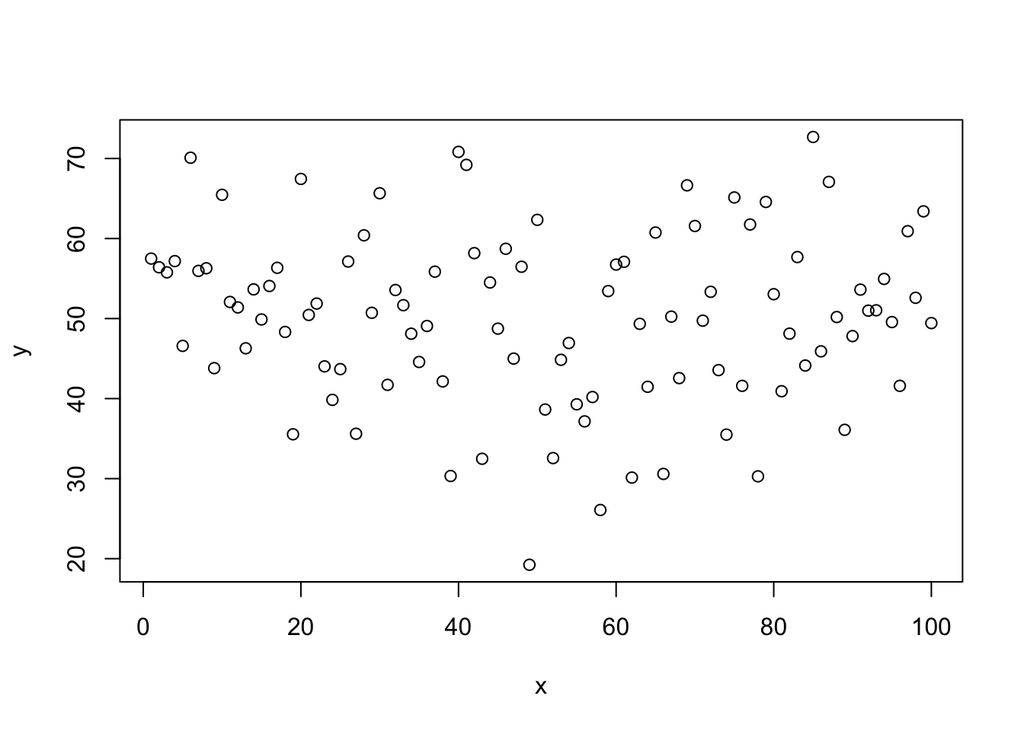

```r
with(plot_data, plot(x, y))
```

```r
#library(ggplot2)
#ggplot(data = plot_data) +
#  geom_point(mapping = aes(x = x, y = y), color = "blue") +
#  ggtitle("x ~ y")
```

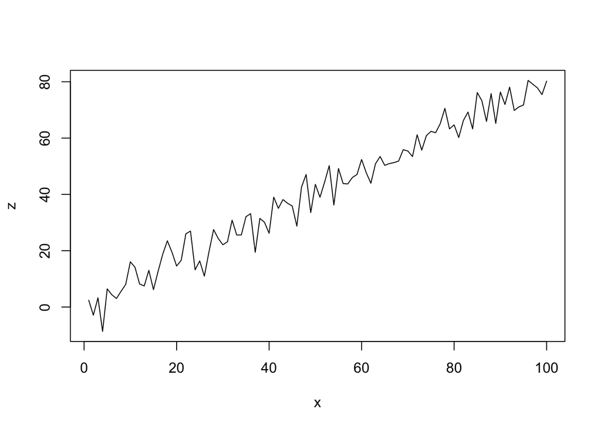

```r
with(plot_data, plot(x, z, type = "l"))
```

```r
#ggplot (data = plot_data) +
#  geom_line(mapping = aes(x = x, y = z), color = "red")
```

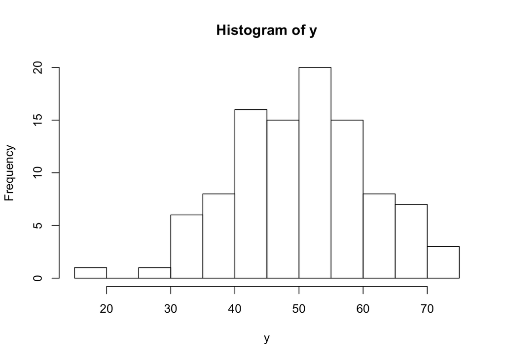

```r
hist(y)
```

## 進階選答題

### Problem A (10%)

這一題我們會用到R的內建資料集，CO2，你可以用`help(CO2)`查詢該資料內的變項和說明。 我們現在想要整理這筆資料，計算Treatment和Type兩變項下各四個情境的uptake平均數 (mean)。 您可以先用head, plot, unique, table等函數看看資料內容，然後用課堂上講到的for迴圈、mean函數來整理資料。 或者，您也可以不用for迴圈，用R的內建指令或其他套件來完成這個分析。

您分析完成的結果，可能會類似這樣：

```
   Treatment        Type   uptake
1 nonchilled      Quebec  <value>
2    chilled      Quebec  <value>
3 nonchilled Mississippi  <value>
4    chilled Mississippi  <value>
```

#### 評分標準：

- 將資料整理成如上述形式。

```r
#head(CO2)
#dim(CO2)
#summary(CO2)
#plot(CO2)
help("CO2")
#names(CO2)

#unique(CO2$Treatment)
#unique(CO2$Type)

library(dplyr)
sol <- CO2 %>%
  group_by(Treatment, Type) %>%
  summarise(mean(uptake)) %>%
  arrange(Type)

sol
```

```
## # A tibble: 4 x 3
## # Groups:   Treatment [2]
##    Treatment        Type `mean(uptake)`
##       <fctr>      <fctr>          <dbl>
## 1 nonchilled      Quebec       35.33333
## 2    chilled      Quebec       31.75238
## 3 nonchilled Mississippi       25.95238
## 4    chilled Mississippi       15.81429
```

### Problem B (10%)

以下有一個資料產生函數`rn100()`，每呼叫一次它都會產生出100個數值。 請重複呼叫他20次，並把這20次的結果分別以不同顏色，繪製成折線圖，並呈現在同一張圖上。

#### 評分標準：

- 將20條線畫在同一張圖中(5%)。
- 每條線有不同的顏色(5%)。

```r
rn100 <- function() cumsum(rnorm(100, 0, 1))
```

```r
x  <- seq(1:100)
y1 <- rn100()
y2 <- rn100()
y3 <- rn100()
y4 <- rn100()
y5 <- rn100()
y6 <- rn100()
y7 <- rn100()
y8 <- rn100()
y9 <- rn100()
y10 <- rn100()
y11 <- rn100()
y12 <- rn100()
y13 <- rn100()
y14 <- rn100()
y15 <- rn100()
y16 <- rn100()
y17 <- rn100()
y18 <- rn100()
y19 <- rn100()
y20 <- rn100()


df <- tibble(x,y1,y2,y3,y4,y5,y6,y7,y8,y9,y10,y11,y12,y13,y14,y15,y16,y17,y18,y19,y20)
df
```

```
## # A tibble: 100 x 21
##        x         y1          y2        y3          y4        y5
##    <int>      <dbl>       <dbl>     <dbl>       <dbl>     <dbl>
##  1     1 -0.5324130  0.21940937 0.1255200  0.65209883 -1.086022
##  2     2  0.6241217  1.23713187 0.2650116 -0.08450899 -2.294905
##  3     3 -0.5301196  0.26554712 0.4505296 -0.90440753 -3.065137
##  4     4 -1.3014416  0.12206365 2.1072823 -1.83320230 -2.763641
##  5     5 -0.4967668 -1.60746851 1.7603625 -3.49777218 -4.003015
##  6     6 -1.1733904 -0.54817813 2.1128257 -3.38673496 -4.447226
##  7     7 -0.6540328 -2.31507387 2.2470714 -1.72608349 -3.651109
##  8     8 -0.2835289 -2.77805546 3.3001261 -1.50232968 -3.928788
##  9     9 -0.5806924 -1.31151923 3.2339913 -1.83347116 -2.241956
## 10    10  0.5049178 -0.02347006 3.3498792 -1.82601416 -1.124429
## # ... with 90 more rows, and 15 more variables: y6 <dbl>, y7 <dbl>,
## #   y8 <dbl>, y9 <dbl>, y10 <dbl>, y11 <dbl>, y12 <dbl>, y13 <dbl>,
## #   y14 <dbl>, y15 <dbl>, y16 <dbl>, y17 <dbl>, y18 <dbl>, y19 <dbl>,
## #   y20 <dbl>
```

```r
#dim(df)
```

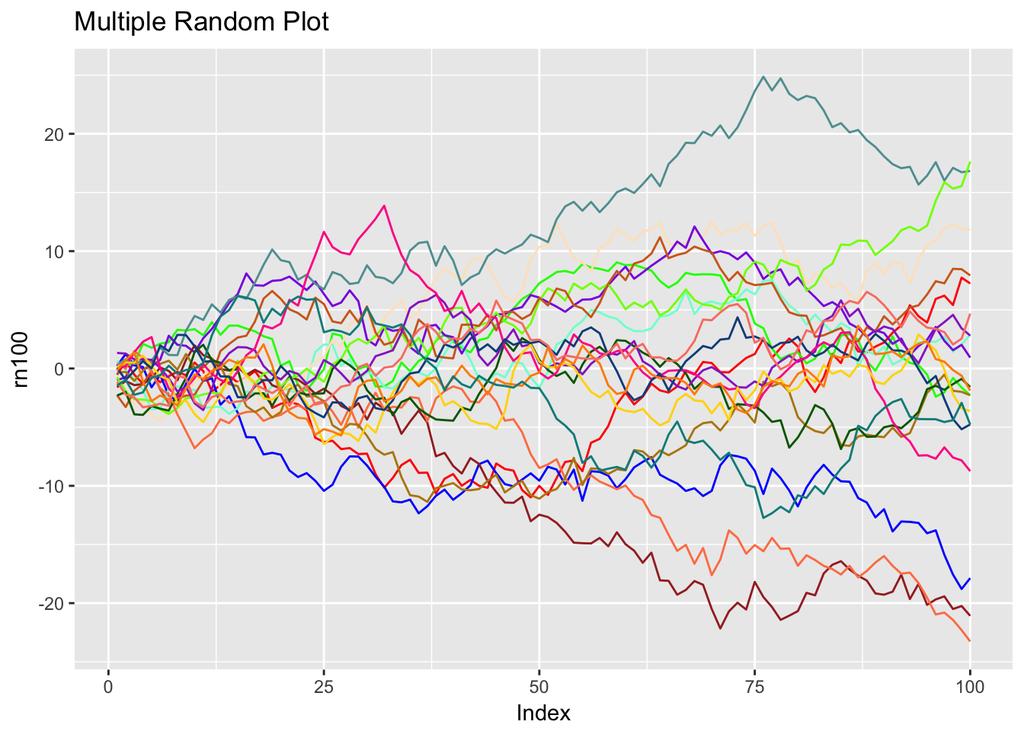

```r
library(ggplot2)

ggplot(df, aes(x)) +                    # basic graphical object
  geom_line(aes(y=y1), colour = "red") +  # first layer
  geom_line(aes(y=y2), colour = "blue") +
  geom_line(aes(y=y3), colour = "green") +
  geom_line(aes(y=y4), colour = "aquamarine") +
  geom_line(aes(y=y5), colour = "bisque") +
  geom_line(aes(y=y6), colour = "blueviolet") +
  geom_line(aes(y=y7), colour = "brown") +
  geom_line(aes(y=y8), colour = "cadetblue") +
  geom_line(aes(y=y9), colour = "chartreuse") +
  geom_line(aes(y=y10), colour = "chocolate") +
  geom_line(aes(y=y11), colour = "coral") +
  geom_line(aes(y=y12), colour = "darkgoldenrod") +
  geom_line(aes(y=y13), colour = "darkgreen") +
  geom_line(aes(y=y14), colour = "darkorchid") +
  geom_line(aes(y=y15), colour = "deeppink") +
  geom_line(aes(y=y16), colour = "gold") +
  geom_line(aes(y=y17), colour = "dodgerblue4") +
  geom_line(aes(y=y18), colour = "darkorange") +
  geom_line(aes(y=y19), colour = "salmon") +
  geom_line(aes(y=y20), colour = "darkcyan") +
  labs(title = "Multiple Random Plot", x = "Index", y = "rn100")
```